# Short ALAAM

## Download and extract data

We are looking at the s50 dataset, which is further described here: https://www.stats.ox.ac.uk/~snijders/siena/s50_data.htm

This dataset is available in ziped format online.

```r
temp <- tempfile()
download.file("https://www.stats.ox.ac.uk/~snijders/siena/s50_data.zip",temp)
adj <- read.table(unz(temp, "s50-network1.dat"))
sport <- read.table(unz(temp, "s50-sport.dat"))
smoke.raw <- read.table(unz(temp, "s50-smoke.dat"))
alcohol <- read.table(unz(temp, "s50-alcohol.dat"))
unlink(temp)
```

Format the network and set smoke at the second wave as our outcome variable

```r
n <- nrow(adj)
adj <- as.matrix(adj) # convert from data.frame to matrix
smoke <- smoke.raw[,2] # use wave 2
smoke[smoke<2] <- 0 # set non-smoker to 0
smoke[smoke>0] <- 1 # set occasional and regular to 1
smoke[c(1:2)] <- NA # let person 1 and 2 be non-respondents
```

## Load ALAAM routines

Download the script ‘MultivarALAAMalt.R’ and read in the routines

```r
source('MultivarALAAMalt.R')
```

### Format covariates

For a Markov model (Robins, Pattison, and Elliott 2001), the sufficient statistics are, degrees $x_{i\cdot}=\sum_j x_{ij}$, two-stars $\binom{x_{i\cdot}}{2}$, three-stars $\binom{x_{i\cdot}}{3}$, and triangles $\sum_{j,k \neq i}x_{ij}x_{ik}x_{jk}$. These can be be pre-calculated and used as monadic covariates

```r
out.degree <-matrix( rowSums(adj), n, 1) # number of ties sent
rec.ties <-  matrix( rowSums(adj * t(adj) ), n , 1) # number of ties that are mutual
```

Format covariates by putting them al into a matrix (the column names are only required for formatting the output)

```r
covs <- cbind(sport[,1],
              alcohol[,1],
              out.degree,
              rec.ties)
colnames(covs) <- c("Sport",
                    "Alcohol",
                    "outdegree",
                    "reciprochation")
head(covs)
```

```
##      Sport Alcohol outdegree reciprochation
## [1,]     2       3         2              1
## [2,]     1       2         2              2
## [3,]     1       2         2              2
## [4,]     2       2         2              2
## [5,]     2       3         1              1
## [6,]     2       4         1              1
```

### Dyad independent Markov model

```r
res.0 <- BayesALAAM(y = smoke,           # dependent variable
                    ADJ = adj,           # network
                    covariates = covs,   # covariates
                    directed = TRUE,    # directed / undirecred network
                    Iterations = 1000,   # number of iterations
                    saveFreq = 100,      # print and save frequency
                    contagion = 'none')  # type of contagion
```

```
## [1] "you have  2  missing entries in response"
## NULL
```

```
## [1] "you have chosen directed equals  TRUE"
## [1] "you have chosen degree equals  FALSE"
## [1] "you have p:  6"
##
## observed stats:  16 21 27 57 41 24
## number of covariates:  4Estimation using pseudo likelihood:
##
## you have done  100  iterations out of  1000
## theta: -6.054 0 -1.523 2.807 1.985 -3.399
## you have done  200  iterations out of  1000
## theta: -2.434 0 -1.235 1.926 1.117 -2.823
## you have done  300  iterations out of  1000
## theta: -6.769 0 -0.845 1.941 1.134 -1.334
## you have done  400  iterations out of  1000
## theta: -1.875 0 -2.594 2.334 1.435 -3.414
## you have done  500  iterations out of  1000
## theta: -6.76 0 -0.351 2.615 1.495 -2.787
## you have done  600  iterations out of  1000
## theta: -4.363 0 0.793 1.124 1.09 -1.922
## you have done  700  iterations out of  1000
## theta: -6.785 0 -1.166 2.365 1.215 -1.696
## you have done  800  iterations out of  1000
## theta: -0.021 0 -1.448 0.97 0.865 -1.917
## you have done  900  iterations out of  1000
## theta: -0.274 0 -1.421 0.876 0.44 -0.977
## you have done  1000  iterations out of  1000
## theta: -2.723 0 -0.828 0.958 0.79 -1.129
## summaries of the posterior draws:
##                       mean          sd         ESS     SACF 10     SACF 30
## intercept      -3.57528827  1.84370633 65.48931273  0.27785266 -0.02597620
## contagion       0.00000000  0.00000000  0.00000000
## Sport          -0.89574155  0.79838336 46.23780424  0.43664621  0.17101907
## Alcohol         1.59535078  0.56384428 25.91285992  0.58538240  0.26772790
## outdegree       1.02998164  0.41662032 46.04220011  0.36063973 -0.16818053
## reciprochation -1.88264969  0.80403546 24.74350603  0.57084758  0.01574423
##
## if ESS is small you need to increase the number of Iterations
## or adjust the proposals by improving the proposal variance-covariance:
## e.g. set PropSigma equal to the covariance of the posterior draws, or
## increase the scaling of the porposals (defaul: scaling=1)
```

### Goodness of fit

If you want to supply a covariate to evaluate in the GOF, you can do that by supplying `user.covars`. For example, let us use the proportion of alcohol in alter

```r
user.covars <- as.data.frame(adj %*% matrix(alcohol[,1],n,1 )/(out.degree +1 ))
names(user.covars) <- 'prop.alc.alter'
```

```r
sim.0 <- get.gof.distribution(NumIterations=500, # number of vectors to draw
                                  res=res.0, # the ALAAM estimation object that contains model and results
                                  burnin=100, # no. iterations discarded from GOF distribution
                                  thinning = 1000, # no. iterations between sample points
                                  contagion ='none',# should be the same as for model fitted
                              user.covars = user.covars) # the gof will now evaluate the fit for this covariate
```

```
## Simulating GOF took  8.878199
## user supplied covaraites, user.covars, must be class matrix
## Calculating statistics took  1.039216
```

```r
gof.table(obs.stats=    sim.0$stats, # observed statistics included  not fitted statistics
          sim.stats=    sim.0$Sav.gof, # simulated goodness-of-fit statistics
          name.vec= sim.0$gof.stats.names, # names of statistics calculate, not all will be used if undirected
          tabname='ALAAMGofalt', # name of file saved
          pvalues=TRUE, # posterior predictive p-values
          save.tab ='csv', # save a csv file or a LaTex file
          directed=TRUE,
          Imp.gof = sim.0$Imp.gof)
```

```
##                       obs     mean    p-val
## intercept        16.47600 16.09200  0.18500
## simple cont.     22.51200 19.59400  0.15900
## recip cont.       5.56000  5.21000  0.16700
## indirect cont.   50.53200 37.36200  0.10200
## closedind cont.  22.39200 18.87600  0.14600
## transitive cont. 13.78400 11.12600  0.19300
## outdegree        41.95200 40.89600  0.21100
## indegree         38.56000 41.84800  0.17000
## reciprochation   24.56000 24.76600  0.22900
## instar           56.08400 61.53000  0.17700
## outstar          43.47600 42.32200  0.22600
## twopath          86.56000 95.36200  0.17400
## in3star          71.00000 67.34200  0.31800
## out3star         22.00000 21.66200  0.24500
## transitive       34.39200 33.63200  0.21800
## cyclic           18.00000 22.11000  0.10400
## indirect         91.29600 84.46400  0.17600
## excl.indirect    50.90400 46.03200  0.17000
## prop.alc.alter   39.98067 37.48520  0.18700
```

| GOF-name | interpretation | statistic |
| --- | --- | --- |
| intercept | intercept | $\sum y_{i}$ |
| simple cont. | direct contagion through outgoing ties | $\sum y_{i}y_{j}x_{i,j}$ |
| recip cont. | contagion through reciprochated ties | $\sum y_{i}y_{j}x_{i,j}x_{j,i}$ |
| indirect cont. | indirect contagion | $\sum_{j,k}y_ix_{i,j}x_{j,k}y_k$ |
| closedind cont. | contaigion in closed triad | $\sum_{j,k}y_ix_{i,j}x_{j,k}x_{i,k}y_k$ |
| transitive cont. | contagion in transitive triple | $\sum_{j,k}x_{i,j}x_{j,k}x_{i,k}y_iy_jy_k$ |
| outdegree | Markov outdegree | $\sum y_{i}\sum_j x_{i,j}$ |
| indegree | Markov outdegree | $\sum y_{i}\sum_j x_{j,i}$ |
| reciprochation | Markov reciprochal ties | $\sum y_{i}\sum_j x_{i,j}x_{i,j}$ |
| instar | Markov in-star | $\sum y_{i} {\binom{\sum_j x_{i,j}}{2}}$ |
| outstar | Markov out-star | $\sum y_{i} {\binom{\sum_j x_{j,i}}{2}}$ |
| twopath | Markov mixed star | $\sum y_{i} \sum x_{i,j}x_{i,k}$ |
| in3star | Markov in-three star | $\sum y_{i} \sum x_{j,i}x_{k,i}x_{h,i}$ |
| out3star | Markov out-three star | $\sum y_{i} \sum x_{i,j}x_{i,k}x_{i,h}$ |
| transitive | Markov transitive triangle | $\sum y_i \sum_{j,k}x_{i,j}x_{j,k}x_{i,k}$ |
| cyclic | Markov cyclic triangle | $\sum y_i \sum_{j,k}x_{i,j}x_{j,k}x_{k,i}$ |
| indirect | Markov indirect, non-exclusive ties | $\sum_{j} (x_{i,j} x_{j, +} - x_{i,j}x_{j,i})$ |
| excl.indirect | Markov indirect, unique nodes | $\sharp \{ k : x_{ik}=0,\max_j(x_{i,j}x_{j,k})>0 \}$ |
| prop.alc.alter | a user-defined alter attribute variable | $\frac{1}{1+x_{i,+}} \sum x_{i,j}a_{j}$ |

## Model selection

We may evaluate the deviance
$$D(\theta) = - 2 \ell (\theta ; y)$$
for values $\theta_1,\ldots,\theta_G$ from our posterior draws, where $\ell (\theta ; y)$ is the log-likelihood. Details are found in Koskinen and Daraganova (2020).

### Posterior deviances for Markov models

#### Evaluate the likelihood

For a Markov model we can evaluate the likelihood analytically.

```r
N.sim <- dim(res.0$Thetas)[1]
p <- dim(res.0$Thetas)[2]
# total points at which deviance calcualted:
thinning <- 5
burnin <- 10
pick.samples <- seq(burnin,N.sim,by=thinning) # this is just picking out thinned sample points
Tot.Samp <- length(pick.samples) # this is because the function aitkinPostDev thins your posterior sample
Tot.Samp
```

```
## [1] 199
```

```r
ind.like <- matrix(0,Tot.Samp,1)
for (k in c(1:Tot.Samp))
{
  theta.ref <- res.0$Thetas[pick.samples[k], c(1,3:p) ] # note: we discard of the contagion parameter that is set to 0
  ind.like[k] <- independLike(ALAAMobj=res.0$ALAAMobj, # this should be the same estimation object as for aitkinPostDev
                             theta=theta.ref # these are the independent model parameters we estimated earlier
                             )
}
```

#### Calcualting the deviance

Same as for the contagion models we combine the likelihoods into the combined deviances

```r
dev.ind <- -2*ind.like
```

## Fitting a contagion model

```r
res.1 <- BayesALAAM(y = smoke,           # dependent variable
                    ADJ = adj,           # network
                    covariates = covs,   # covariates
                    directed = TRUE,    # directed / undirecred network
                    burnin = 1000,
                    Iterations = 5000,   # number of iterations
                    saveFreq = 500)
```

```
## [1] "you have  2  missing entries in response"
## NULL
```

```
## [1] "you have chosen directed equals  TRUE"
## [1] "you have chosen degree equals  FALSE"
## [1] "you have p:  6"
##
## observed stats:  16 21 27 57 41 24
## number of covariates:  4
## you have done  500  iterations out of  5000
## theta: -4.022 -0.385 -1.295 2.129 1.9 -3.244
## observed stats:  16 21 27 57 41 24
##
## imputed ones:  0  out of  2
##
## you have done  1000  iterations out of  5000
## theta: -3.952 0.889 0.268 1.048 0.231 -1.472
## observed stats:  17 24 29 60 43 25
##
## imputed ones:  1  out of  2
##
## you have done  1500  iterations out of  5000
## theta: -9.093 0.553 0.496 2.806 0.689 -2.723
## observed stats:  17 24 29 60 43 25
##
## imputed ones:  1  out of  2
##
## you have done  2000  iterations out of  5000
## theta: -2.836 0.107 -1.554 1.756 0.788 -2.082
## observed stats:  17 24 29 60 43 25
##
## imputed ones:  1  out of  2
##
## you have done  2500  iterations out of  5000
## theta: -3.044 0.883 -1.267 1.877 1.544 -4.069
## observed stats:  17 24 29 60 43 25
##
## imputed ones:  1  out of  2
##
## you have done  3000  iterations out of  5000
## theta: -2.051 0.143 -0.149 0.273 0.702 -0.585
## observed stats:  17 24 29 60 43 25
##
```

[output cut: 24 more lines]

```
## imputed ones:  0  out of  2
##
## summaries of the posterior draws:
##                       mean          sd         ESS     SACF 10     SACF 30
## intercept       -3.8608634   2.2138837  88.2118926   0.6812100   0.3741362
## contagion        0.4352769   0.3087600 117.8867761   0.6018109   0.2385068
## Sport           -0.3149046   0.8777700  92.2131546   0.6731714   0.3082063
## Alcohol          1.2991063   0.5110833  87.0144629   0.6728119   0.3571273
## outdegree        0.6816382   0.4603336  96.4256319   0.6452927   0.3024063
## reciprochation  -1.7761068   0.8724797  64.8354197   0.7455873   0.4381616
##
## if ESS is small you need to increase the number of Iterations
## or adjust the proposals by improving the proposal variance-covariance:
## e.g. set PropSigma equal to the covariance of the posterior draws, or
## increase the scaling of the porposals (defaul: scaling=1)
```

### Goodness of fit

```r
sim.1 <- get.gof.distribution(NumIterations=500, # number of vectors to draw
                                  res=res.1, # the ALAAM estimation object that contains model and results
                                  burnin=100, # no. iterations discarded from GOF distribution
                                  thinning = 1000, # no. iterations between sample points
                                  contagion ='none',# should be the same as for model fitted
                              user.covars = user.covars) # the gof will now evaluate the fit for this covariate
```

```
## Simulating GOF took  8.975977
## user supplied covaraites, user.covars, must be class matrix
## Calculating statistics took  1.140125
```

```r
gof.table(obs.stats=    sim.1$stats, # observed statistics included  not fitted statistics
          sim.stats=    sim.1$Sav.gof, # simulated goodness-of-fit statistics
          name.vec= sim.1$gof.stats.names, # names of statistics calculate, not all will be used if undirected
          tabname='ALAAMGof', # name of file saved
          pvalues=TRUE, # posterior predictive p-values
          save.tab ='csv', # save a csv file or a LaTex file
          directed=TRUE,
          Imp.gof = sim.1$Imp.gof)
```

```
##                        obs      mean     p-val
## intercept         16.73200  17.46800   0.18800
## simple cont.      23.36600  25.06000   0.20900
## recip cont.        5.90200   6.85000   0.16500
## indirect cont.    52.22800  48.72000   0.19900
## closedind cont.   22.56200  22.13400   0.23600
## transitive cont.  14.12400  13.07800   0.20400
## outdegree         42.46400  47.16200   0.14300
## indegree          38.90200  45.07600   0.12200
## reciprochation    24.90200  27.35800   0.16400
## instar            56.17000  63.55400   0.16600
## outstar           43.73200  51.52000   0.12300
## twopath           86.90200 107.01200   0.10000
## in3star           71.00000  66.80200   0.30000
## out3star          22.00000  28.41400   0.11100
## transitive        34.56200  39.18000   0.13100
## cyclic            18.00000  24.55800   0.06100
## indirect          92.49000 102.57200   0.15200
## excl.indirect     51.92800  57.05600   0.16100
## prop.alc.alter    40.69200  41.03677   0.23900
```

### Posterior deviances for the contagion model

#### Evaluate the likelihood

Evaluating the likelihood is time-consuming so let us try to economise on the number of sample points we use.

Let us assume that we have `num.imps` imputed networks. The total evaluations `Tot.Samp` that we get from `aitkinPostDev` depends on the size of the posterior sample `dim(res.1$Thetas)[1]` as well as the thinning and burnin

```r
N.sim <- dim(res.1$Thetas)[1]
# total points at which deviance calculated:
thinning <- 20
burnin <- 1000
Tot.Samp <- length(seq(burnin,N.sim,by=thinning)) # this is because the function aitkinPostDev thinns your posterior sample
Tot.Samp
```

```
## [1] 201
```

If we have a large `num.imps` we do not need `Tot.Samp` to be too big. Aim to get the total `num.imps*Tot.Samp` in the range 500 to 1000.

#### Setting the number of vectors Y that are use to estimat likelihood

For a certain number of bridges the (log) ratio of normalising constants are evaluated based on a draw of $Y$ from the ALAAM. This sample size does not have to be too big. A sample size `numYsamps` that is 100 is good but to save time we can probably get away with 30.

```r
numYsamps <- 30
```

### Evaluate the posterior deviances

Evaluating the likelihood will take some time.

```r
logit.est <- glm(res.1$ALAAMobj$y~res.1$ALAAMobj$covariates, family = binomial(link = "logit"))
p <- dim(res.1$Thetas)[2]
thetaRef <- matrix(0,p,1)
thetaRef[1] <- summary(logit.est)$coef[1,1]
thetaRef[3:p] <- summary(logit.est)$coef[2:(p-1),1]
relLike.1 <- aitkinPostDev(ALAAMresult=res.1,# the ALAAM results object
                           burnin=burnin , # number of parameter draws to be discarded - should eliminate dependence on initial conditions
                           thinning=thinning, # model selection is more sensitive to serial autocorrelation than point estimates and standard deviations
                           numYsamps=numYsamps, # number of simulated vectors to base Metropolis expectation on
                           thetaRef=t(thetaRef), # input the parameters used for reference for evaluating independent likelihood
                           numbridges=20, # 20 bridges should be enough but more will give higher precision
                           Yburnin=1000)
```

```
##
## usersupplied parameter will be used for reference parameters
##
## you have done  10  iterations out of  201
##
## you have done  20  iterations out of  201
##
## you have done  30  iterations out of  201
##
## you have done  40  iterations out of  201
##
## you have done  50  iterations out of  201
##
## you have done  60  iterations out of  201
##
## you have done  70  iterations out of  201
##
## you have done  80  iterations out of  201
##
## you have done  90  iterations out of  201
##
## you have done  100  iterations out of  201
##
## you have done  110  iterations out of  201
##
## you have done  120  iterations out of  201
##
## you have done  130  iterations out of  201
##
## you have done  140  iterations out of  201
##
## you have done  150  iterations out of  201
##
## you have done  160  iterations out of  201
##
## you have done  170  iterations out of  201
##
## you have done  180  iterations out of  201
##
## you have done  190  iterations out of  201
##
## you have done  200  iterations out of  201
```

```r
indeploglike.1 <- independLike(ALAAMobj=res.1$ALAAMobj, # this should be the same estimation object as for aitkinPostDev
                               theta=thetaRef[c(1,3:p)] # these are the independent model parameters we estimated earlier
                               )

dev <- -2*(relLike.1*(20/21)+as.numeric(indeploglike.1))# this is the estimated deviances for the first network imputation
```

## Compare deviances for Markov

Plot the posterior deviances

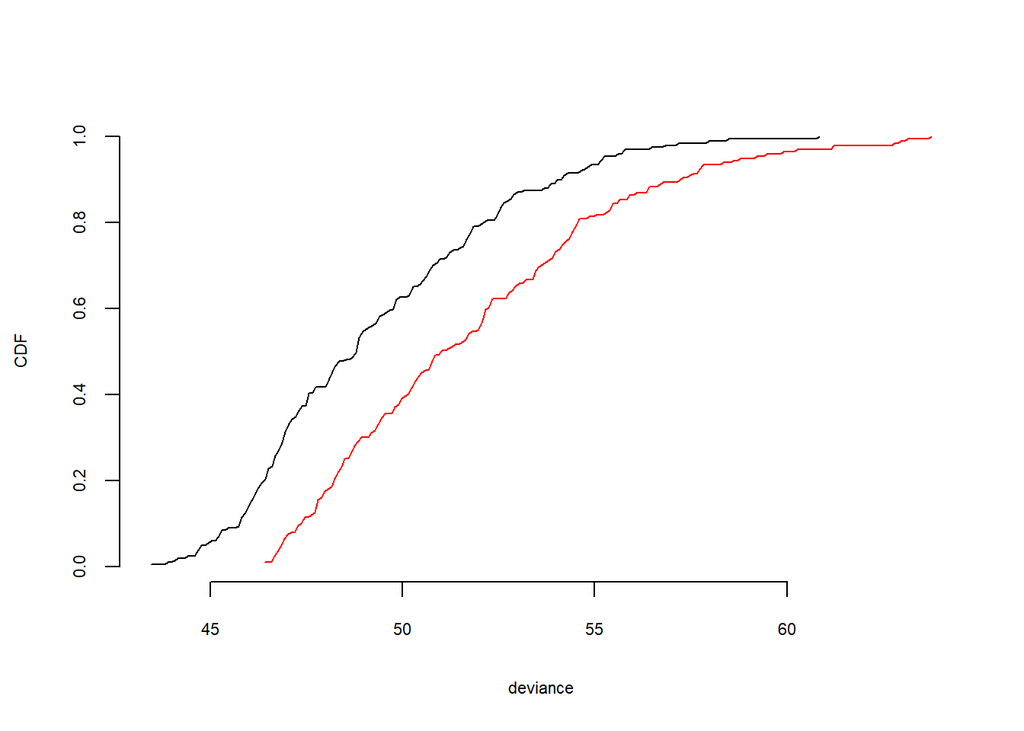

```r
muppet <- ecdf(dev)
xa <- seq(min(dev),max(dev),length.out = 200)
plot(xa ,muppet(xa  ),
     type='l',bty='n' ,
     xlab='deviance',
     ylab='CDF',
     cex.lab=.7,cex.axis=0.7,
     xlim=range(c(dev, dev.ind)))
muppet <- ecdf(dev.ind)
xa <- seq(min(dev.ind),max(dev.ind),length.out = 200)
lines( xa ,muppet(xa  ) , col='red' )# the posterior deviances for the Markov models
```

> If there is clear blue water between the CDFs, then the deviances are said to be stochastically ordered and there is support for the model with the CDF to the lefts

# References

Koskinen, Johan, and Galina Daraganova. 2020. “Bayesian Analysis of Social Influence.” *arXiv Preprint arXiv:2006.16464*.

Robins, Garry, Philippa Pattison, and Peter Elliott. 2001. “Network Models for Social Influence Processes.” *Psychometrika* 66 (2): 161–89.